# Project 2: Data Mining, Classification, Prediction

SDS322E

# Mining, Classification, Prediction

## Gurleen Grewal, gkg422

### Introduction

I picked a dataset from https://vincentarelbundock.github.io/Rdatasets/datasets.html. The dataset, “Clothing,” includes information about 60 random customers who shop at a retail store. This is a dataframe with 60 observations on the following 8 variables. This dataframe contains the variables, ID, which is the ID case; Amount, which is the net dollar amount spent by customers in their latest purchase from this retailer; Recency, which represents the number of months since the last purchase;Freq12 is the number of purchases in the last 12 months; Dollar12 is the dollar amount of purchases in the last 12 months; Freq24 is the number of purchases in the last 24 months; Dollar24 is the dollar amount of purchases in the last 24 months; Card is the binary variable which represents 1 for customers who have a private-label credit card with the retailer, 0 if not. This dataset is contained in the “Stat2Data” package.

I found this dataset interesting since it includes a range of variables that can help predict a person’s spending habits and what influences those spending habits. Working in retail for the last 3 years has made this project very interesting for me. It can also help me predict and analyze my spending habits and make me budget better.

In this dataset, I ended up removing the “recency” variable which I thought was not valuable for analyzing the results of this dataset.

```r
library(tidyverse)
clothing <- read_csv(file = "Clothing.csv")
newclothes <- clothing %>% select(-Recency, -X1) %>% na.omit()
```

### Cluster Analysis

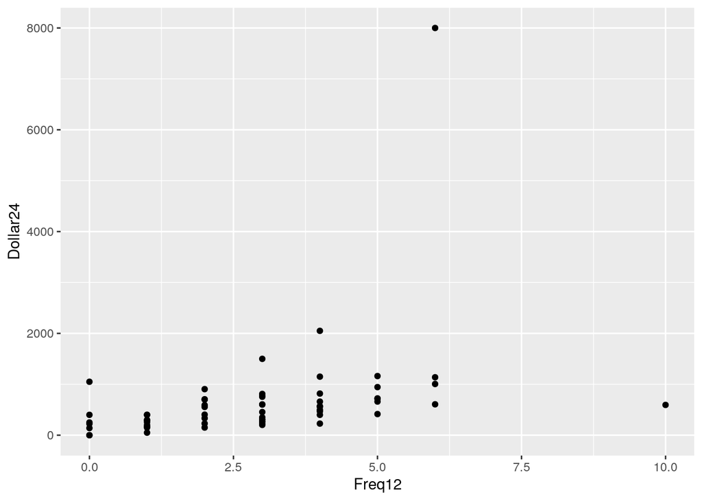

```r
library(cluster)
library(ggplot2)
library(GGally)

newclothes %>% ggplot() + geom_point(aes(Freq12, Dollar24))
```

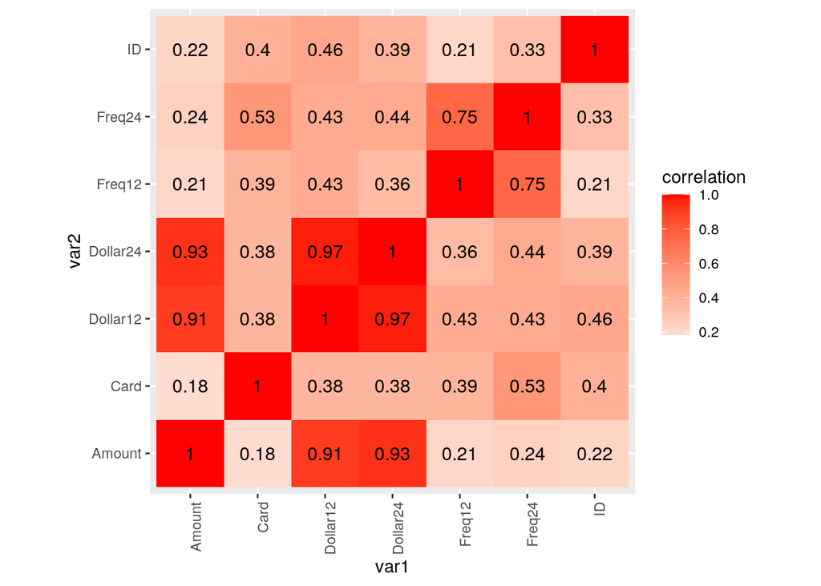

```r
cormat <- newclothes %>% select_if(is.numeric) %>% cor(use = "pair")
tidycor <- cormat %>% as.data.frame %>% rownames_to_column("var1") %>%
    pivot_longer(-1, names_to = "var2", values_to = "correlation")
tidycor %>% ggplot(aes(var1, var2, fill = correlation)) + geom_tile() +
    scale_fill_gradient2(low = "pink", mid = "white", high = "red") +
    geom_text(aes(label = round(correlation, 2)), color = "black",
        size = 4) + theme(axis.text.x = element_text(angle = 90,
    hjust = 1)) + coord_fixed()
```

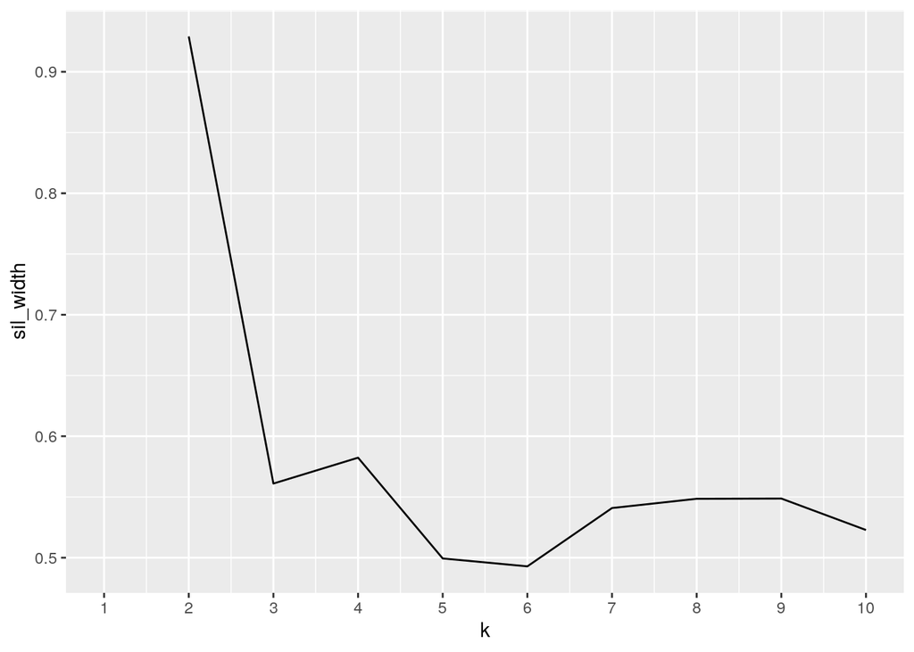

```r
wss <- vector()
for (i in 1:10) {
    temp <- newclothes %>% select(Freq12, Dollar24) %>% kmeans(i)
    wss[i] <- temp$tot.withinss
}
clust_dat <- newclothes %>% dplyr::select(Freq12, Dollar24)

sil_width <- vector()
for (i in 2:10) {
    kms <- kmeans(clust_dat, centers = i)  #compute k-means solution for each k
    sil <- silhouette(kms$cluster, dist(clust_dat))  #get sil widths
    sil_width[i] <- mean(sil[, 3])  #take averages (higher is better)
}
ggplot() + geom_line(aes(x = 1:10, y = sil_width)) + scale_x_continuous(name = "k",
    breaks = 1:10)
```

```r
pam1 <- clust_dat %>% pam(k = 2)
pam1
```

```
## Medoids:
##      ID Freq12 Dollar24
## [1,] 31      3      455
## [2,] 60      6     8000
## Clustering vector:
##  [1] 1 1 1 1 1 1 1 1 1 1 1 1 1 1 1 1 1 1 1 1 1 1 1 1 1 1 1 1 1 1 1 1 1 1 1 1 1 1
## [39] 1 1 1 1 1 1 1 1 1 1 1 1 1 1 1 1 1 1 1 1 1 2
## Objective function:
##    build     swap
## 276.2118 276.2118
##
## Available components:
##  [1] "medoids"    "id.med"     "clustering" "objective"  "isolation"
##  [6] "clusinfo"   "silinfo"    "diss"       "call"       "data"
```

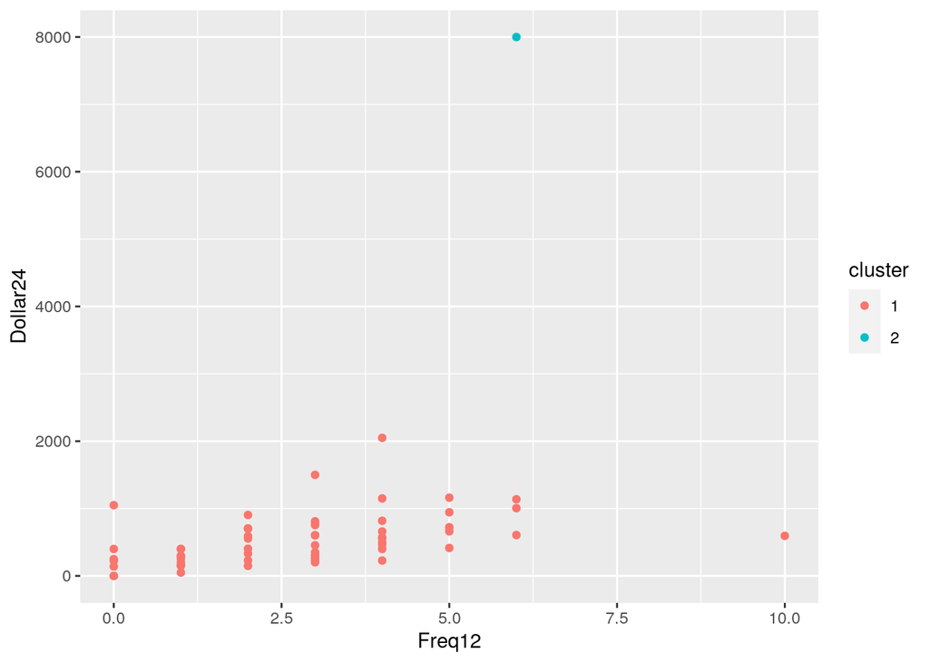

```r
pamclust <- clust_dat %>% mutate(cluster = as.factor(pam1$clustering))
pamclust %>% ggplot(aes(Freq12, Dollar24, color = cluster)) +
    geom_point()
```

```r
pam1$silinfo$avg.width
```

```
## [1] 0.9291277
```

```r
# CLustering with three or more variables

new3 <- newclothes %>% select(Freq12, Freq24, Dollar12, Dollar24) %>%
    as.data.frame() %>% na.omit()
pam2 <- new3 %>% pam(2)
pam2
```

```
## Medoids:
##    ID Freq12 Freq24 Dollar12 Dollar24
## 24 24      4      7      256      468
## 60 60      6     11     5000     8000
## Clustering vector:
##  1  2  3  4  5  6  7  8  9 10 11 12 13 14 15 16 17 18 19 20 21 22 23 24 25 26
##  1  1  1  1  1  1  1  1  1  1  1  1  1  1  1  1  1  1  1  1  1  1  1  1  1  1
## 27 28 29 30 31 32 33 34 35 36 37 38 39 40 41 42 43 44 45 46 47 48 49 50 51 52
##  1  1  1  1  1  1  1  1  1  1  1  1  1  1  1  1  1  1  1  1  1  1  1  1  1  1
## 53 54 55 56 57 58 59 60
##  1  1  1  1  1  1  1  2
## Objective function:
##    build     swap
## 349.6515 349.6515
##
## Available components:
##  [1] "medoids"    "id.med"     "clustering" "objective"  "isolation"
##  [6] "clusinfo"   "silinfo"    "diss"       "call"       "data"
```

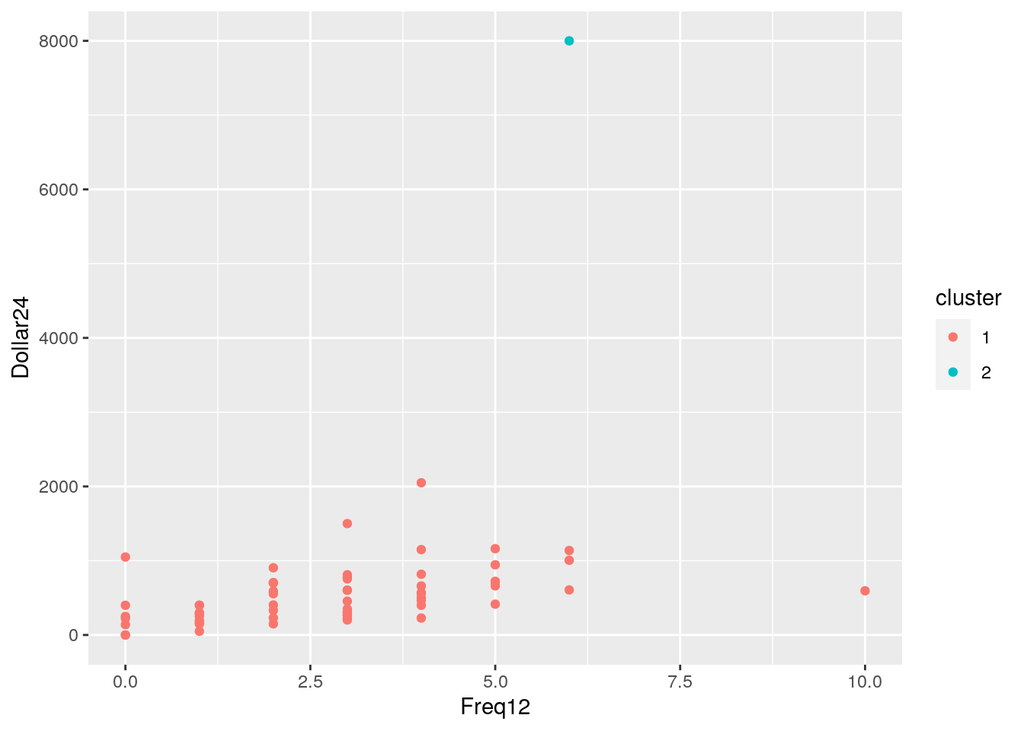

```r
new3 <- new3 %>% mutate(cluster = as.factor(pam2$clustering))
ggplot(new3, aes(x = Freq12, y = Dollar24, color = cluster)) +
    geom_point()
```

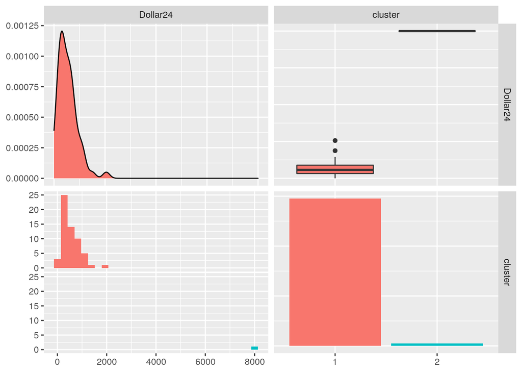

```r
library(GGally)
ggpairs(new3, columns = 4:5, aes(color = cluster))
```